# machineLearningLowBirthRate

This study will use logistics regression to predict if an infant has a low birth weight.

Low birth weight, defined as weight less than 2500 grams, is an outcome that has been a concern to medical physicians for years. Infant mortality rates and congenital disability rates are very high for low birth weight babies. A woman’s behavior (such as diet, smoking habits, and receiving prenatal care) during pregnancy can significantly alter the chance of carrying the baby to term, and consequently, of delivering a baby of healthy birth weight. The low birth weight data includes infant ID number, birth weight, smoker or non-smoker, mother’s age, race, history of premature labor, history of hypertension, presence of uterine irritability, and the number of physicians visited during the first trimester. The goal of this study is to determine whether these factors could be critical predictors of low birth weight.

- Low Birth Rate Data
- Load Libraries
- Access data
- Explore Data
- Parse Data
- Split Data into Training and Test set
- Build Logistic Regression Model
- Predict for Test data
- Evaluate the Model
- ROC curve plot

## Low Birth Rate Data

Analyze the random sample of low birth rate data.

Dataset source Hosmer, D.W., Lemeshow, S. and Sturdivant, R.X. (2013) Applied Logistic Regression, 3rd ed., New York: Wiley

The low birth weight dataset is also part of the aplore3 R package.

[output not shown]

## Load Libraries

Load the Spark and Python Libraries need for the notebook environment.

Run the following cell to load the necessary libraries for the notebook:

```python
# PySpark Machine Learning Library
from pyspark.ml import Pipeline
from pyspark.ml.classification import LogisticRegression
from pyspark.ml.feature import HashingTF, Tokenizer
from pyspark.sql import Row, SQLContext

import os
import sys
from pyspark import SparkConf
from pyspark import SparkContext
from pyspark.sql import SQLContext
from pyspark.sql.types import *

from pyspark.mllib.classification import LogisticRegressionWithSGD
from pyspark.mllib.regression import LabeledPoint
from numpy import array

from pyspark.ml.evaluation import MulticlassClassificationEvaluator
# Library for confusion matrix, precision, test error
from pyspark.mllib.evaluation import MulticlassMetrics
# Library For Area under ROC curve and Area under precision-recall curve
from pyspark.mllib.evaluation import BinaryClassificationMetrics

# Assign resources to the application
sqlContext = SQLContext(sc)

# packages for data analysis
import numpy as np
import pandas as pd
```

```
Waiting for a Spark session to start...
Spark Initialization Done! ApplicationId = app-20200313201637-0000
KERNEL_ID = c0ef8c17-9cf8-4a3a-b717-71359ec956ad
```

```python
# The data file will be loaded into an array.
# This is the summary of the data structure, including the column position and name.
# The first filed starts from position 0.

# 0 ID - Identification Code
# 1 Low - Low birth weight (0: >= 2500, 1: < 2500 g)
# 2 Age
# 3 Race – Race (1: White, 2: Black, 3: Other)
# 4 Smoke - Smoking status during pregnancy (1: No, 2: Yes)
# 5 PTL – History of premature labor (1: None, 2: One, 3: Two, etc.)
# 6 HT - History of hypertension (1: No, 2: Yes)
# 7 UI - Presence of Uterine irritability (1: No, 2: Yes)
# 8 FTV - Number of physician visits during the first trimester (1: None, 2: One, 3: Two, etc.)

# Low is a target variable. The ID is a list of independent variables besides unique identifier
LabeledDocument = Row("ID", "PersonInfo", "label")

#Function that parses each raw in CSV file and returns an object of type LabeledDocument

def parseDocument(line):
    values = [str(x) for x in line.split(',')]
    if (values[1]>'0'):
     Low = 1.0
    else:
      Low = 0.0

     #PersonInfo is the contancation of Age, Race, Smoke, History  of premature labor, History of hypertension,Presence of Uterine irritability, and Number of physician visits during the first trimester
    textValue = str(values[2]) + " " + str(values[3])+" " + str(values[4] + " " + str(values[5]) + " " + str(values[6]) + " " + str(values[7]) + " " + str(values[8]))
    return LabeledDocument(values[0], textValue, Low)
```

## Access Data

To read a file from Object Storage, must setup the Spark configuration with the Object Storage credentials.

To do this, click on the cell below and select the **Insert to code > Insert Spark Session DataFrame** function from the Files tab below the data file to work with.

The following code contains the credentials for a file in your IBM Cloud Object Storage.

```python
import ibmos2spark
# @hidden_cell
credentials = {
    'endpoint': 'https://s3-api.us-geo.objectstorage.service.networklayer.com',
    'service_id': 'iam-ServiceId-a6b68584-eecf-47d8-85b5-511373455a9d',
    'iam_service_endpoint': 'https://iam.ng.bluemix.net/oidc/token',
    'api_key': 'UK90hzAIB2GeyTJMVTMLhXryc5sVxqMWc7SmX7vc_KX0'
}

configuration_name = 'os_0640f79252ae445cbd16161fe82261cd_configs'
cos = ibmos2spark.CloudObjectStorage(sc, credentials, configuration_name, 'bluemix_cos')

from pyspark.sql import SparkSession
spark = SparkSession.builder.getOrCreate()
df_data_1 = spark.read\
  .format('org.apache.spark.sql.execution.datasources.csv.CSVFileFormat')\
  .option('header', 'true')\
  .load(cos.url('lowbwt.csv', 'apachesparktutorial-donotdelete-pr-yvc6mjih2n99vj'))
df_data_1.take(5)
```

```
[Row(ID='85', LOW='0', AGE='19', RACE='2', SMOKE='0', PTL='0', HT='0', UI='1', FTV='0'),
 Row(ID='86', LOW='0', AGE='33', RACE='3', SMOKE='0', PTL='0', HT='0', UI='0', FTV='3'),
 Row(ID='87', LOW='0', AGE='20', RACE='1', SMOKE='1', PTL='0', HT='0', UI='0', FTV='1'),
 Row(ID='88', LOW='0', AGE='21', RACE='1', SMOKE='1', PTL='0', HT='0', UI='1', FTV='2'),
 Row(ID='89', LOW='0', AGE='18', RACE='1', SMOKE='1', PTL='0', HT='0', UI='1', FTV='0')]
```

## Explore Data

Explore the various features to gain some knowlege about the dataset.

```python
# Infer the data type of each column and convert the data to the inferred data type
from ingest import *
eu = ExtensionUtils(sqlContext)
df_data_1=eu.convertTypes(df_data_1)
df_data_1.printSchema()
```

```
root
 |-- ID: short (nullable = true)
 |-- LOW: byte (nullable = true)
 |-- AGE: byte (nullable = true)
 |-- RACE: byte (nullable = true)
 |-- SMOKE: byte (nullable = true)
 |-- PTL: byte (nullable = true)
 |-- HT: byte (nullable = true)
 |-- UI: byte (nullable = true)
 |-- FTV: byte (nullable = true)
```

```python
#View dataframe Columns
df_data_1.columns
```

```
['ID', 'LOW', 'AGE', 'RACE', 'SMOKE', 'PTL', 'HT', 'UI', 'FTV']
```

```python
#Print number of infants
print('Number of Infants:', df_data_1.count())
```

```
Number of Infants: 189
```

```python
#Number of infants with low birth weight and number infants without a low birth weight
df_data_1.groupby('Low').count().show()
```

```
+---+-----+
|Low|count|
+---+-----+
|  1|   59|
|  0|  130|
+---+-----+
```

```
+--------+---+---+
|Race_Low|  0|  1|
+--------+---+---+
|       2| 15| 11|
|       1| 73| 23|
|       3| 42| 25|
+--------+---+---+
```

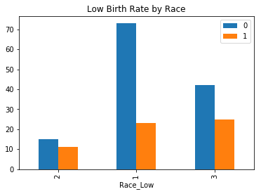

```python
#Number of infants with low birth weight by race
import matplotlib.pyplot as plt
%matplotlib inline
df_data_1.crosstab('Race', 'Low').show()
df=df_data_1.crosstab('Race', 'Low').toPandas()
df.plot.bar(x="Race_Low", legend=True , title="Low Birth Rate by Race")
```

```python
# Average mothers age by low birth rate
# Convert Age data type from string to numeric.
pdf=df_data_1.toPandas()
pdf["AGE"]=pd.to_numeric(pdf.AGE)

df=sqlContext.createDataFrame(pdf)

PAge=df.groupby(['Low'])\
.agg({"AGE": "AVG"}).toPandas()
PAge
```

|  | Low | avg(AGE) |
| --- | --- | --- |
| 0 | 0 | 23.661538 |
| 1 | 1 | 22.305085 |

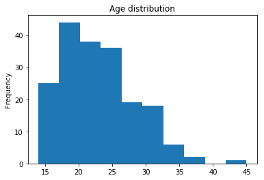

```python
#Age distribution for all mothers
df.toPandas()['AGE'].plot.hist(x="Age", title="Age distribution")
```

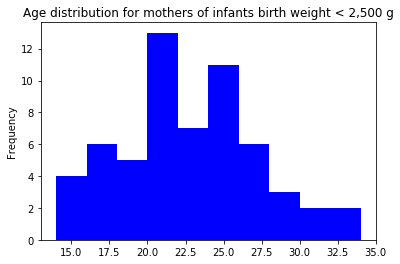

```python
# Age distribution for mothers who infants have birth weight < 2,500 g
df_lbr=df.select('AGE', 'LOW').filter(df['LOW']=='1')
pdf_lbr=df_lbr.select('AGE').toPandas()
pdf_lbr.plot.hist('AGE',  color='b',legend=False, title="Age distribution for mothers of infants birth weight < 2,500 g")
```

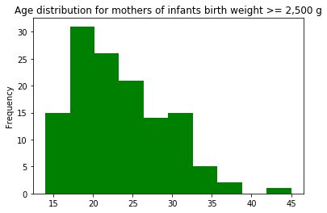

```python
# Age distribution for mothers who infants have birth weight >=  2,500 g
df_lbr=df.select('AGE', 'LOW').filter(df['LOW']=='0')
pdf_lbr=df_lbr.select('AGE').toPandas()
pdf_lbr.plot.hist('AGE',  color='g',legend=False, title="Age distribution for mothers of infants birth weight >= 2,500 g")
```

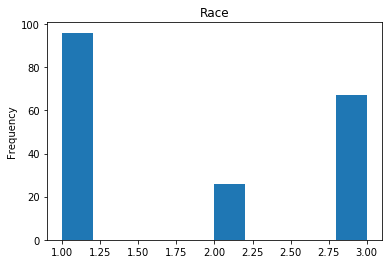

```python
#Race distribution for all mothers
df.toPandas()["RACE"].plot.hist(x="Race", title="Race")
```

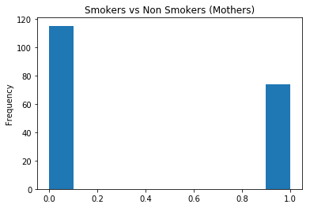

```python
#Number of mothers who smoked during pregancy
df.toPandas()["SMOKE"].plot.hist(x="Smoke", title="Smokers vs Non Smokers (Mothers)")
```

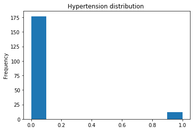

```python
#Number of mothers with history of hypertension
df.toPandas()["HT"].plot.hist(x="HT", title="Hypertension distribution ")
```

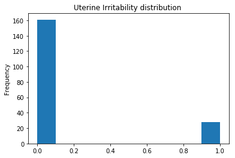

```python
#Number of mother’s presence of Uterine irritability
df.toPandas()["UI"].plot.hist(x="UI", title="Uterine Irritability distribution ")
```

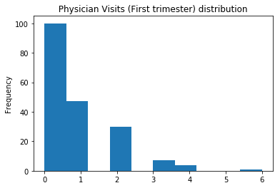

```python
#Number of physician visits during the first trimester
df.toPandas()["FTV"].plot.hist(x="FTV", title=" Physician Visits (First trimester) distribution ")
```

```
+---------+---+---+
|Smoke_Low|  0|  1|
+---------+---+---+
|        1| 44| 30|
|        0| 86| 29|
+---------+---+---+
```

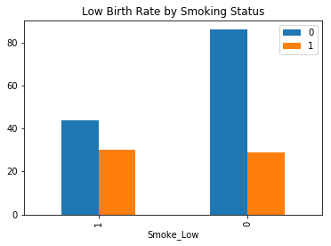

```python
#Number of infants with low birth weight by smoking
import matplotlib.pyplot as plt
%matplotlib inline
df_data_1.crosstab('Smoke', 'Low').show()
df=df_data_1.crosstab('Smoke', 'Low').toPandas()
df.plot.bar(x="Smoke_Low", legend=True , title="Low Birth Rate by Smoking Status")
```

## Parse Data

Load the data into a `Spark RDD` and print the number of rows and show the frist five rows of the RDD. Each project creates a bucket in a object storage. The bucket name from the project Settings page. Replace the string `BUCKET` to the bucket name

```python
data = sc.textFile(cos.url('lowbwt.csv', 'apachesparktutorial-donotdelete-pr-yvc6mjih2n99vj'))
print ("Total records in the data set:", data.count())
print ("The first 5 rows")
data.take(5)
```

```
Total records in the data set: 190
The first 5 rows
```

```
['ID,LOW,AGE,RACE,SMOKE,PTL,HT,UI,FTV',
 '85,0,19,2,0,0,0,1,0',
 '86,0,33,3,0,0,0,0,3',
 '87,0,20,1,1,0,0,0,1',
 '88,0,21,1,1,0,0,1,2']
```

Creates DataFrame from RDD

```python
#Parse and Load the data into a dataframe. The code calls the parsing function defined above
documents = data.filter(lambda s: "Name" not in s).map(parseDocument)
LowBirthData = documents.toDF() # ToDataFrame
print ("Number of records: " + str(LowBirthData.count()))
print ( "First 5 records: ")
LowBirthData.take(5)
```

```
Number of records: 190
First 5 records:
```

```
[Row(ID='ID', PersonInfo='AGE RACE SMOKE PTL HT UI FTV', label=1.0),
 Row(ID='85', PersonInfo='19 2 0 0 0 1 0', label=0.0),
 Row(ID='86', PersonInfo='33 3 0 0 0 0 3', label=0.0),
 Row(ID='87', PersonInfo='20 1 1 0 0 0 1', label=0.0),
 Row(ID='88', PersonInfo='21 1 1 0 0 1 2', label=0.0)]
```

## Split Data into Training and Test set

Divide the data into training and test set for regression analysis. The training data set will be used to build the model while the test data will be used to evaluate the model.

```python
# Divide the data into training and test set Training Data = 80% Test data = 20% and print the frist 20 rows of the training set.
(train, test) = LowBirthData.randomSplit([0.8, 0.2])
print ("Number of records in the training set: " + str(train.count()))
print ("Number of records in the test set: " + str(test.count()))
# Output first 20 records in the training set
print ("First 20 records in the training set: ")
train.show()
```

```
Number of records in the training set: 152
Number of records in the test set: 38
First 20 records in the training set:
+---+--------------+-----+
| ID|    PersonInfo|label|
+---+--------------+-----+
|100|18 1 1 0 0 0 0|  0.0|
|101|18 1 1 0 0 0 0|  0.0|
|102|15 2 0 0 0 0 0|  0.0|
|103|25 1 1 0 0 0 3|  0.0|
|105|28 1 1 0 0 0 1|  0.0|
|106|32 3 0 0 0 0 2|  0.0|
|107|31 1 0 0 0 1 3|  0.0|
|111|25 3 0 0 0 1 2|  0.0|
|112|28 1 0 0 0 0 0|  0.0|
|113|17 1 1 0 0 0 0|  0.0|
|114|29 1 0 0 0 0 2|  0.0|
|115|26 2 1 0 0 0 0|  0.0|
|117|17 2 0 0 0 0 1|  0.0|
|118|24 1 1 1 0 0 1|  0.0|
|119|35 2 1 1 0 0 1|  0.0|
|123|29 1 1 0 0 0 2|  0.0|
|124|19 1 1 0 0 0 2|  0.0|
|125|27 1 1 0 0 0 0|  0.0|
|127|33 1 1 0 0 0 1|  0.0|
|129|19 1 0 0 0 0 2|  0.0|
+---+--------------+-----+
only showing top 20 rows
```

## Build Logistic Regression Model

Use the Pipeline of SparkML to build the Logistic Regression Model

```python
# set up Logistic Regression using Pipeline of SparkML
tokenizer = Tokenizer(inputCol="PersonInfo", outputCol="words")
hashingTF = HashingTF(inputCol=tokenizer.getOutputCol(), outputCol="features")
lr = LogisticRegression(maxIter=10, regParam=0.01)
pipeline = Pipeline(stages=[tokenizer, hashingTF, lr])
```

```python
# set up Logistic Regression Model
# the stages are executed in order
model = pipeline.fit(train)
#[stage.coefficients for stage in model.stages if hasattr(stage, "coefficients")]
# model.stages[2].intercept
```

## Predict for Test data

```python
#Create predictions for test data and print columns of interest
prediction = model.transform(test)
selected = prediction.select("PersonInfo", "prediction", "probability")
for row in selected.collect():
    print (row)
```

```
Row(PersonInfo='20 3 0 0 0 1 0', prediction=0.0, probability=DenseVector([0.6022, 0.3978]))
Row(PersonInfo='36 1 0 0 0 0 1', prediction=0.0, probability=DenseVector([0.9671, 0.0329]))
Row(PersonInfo='28 3 0 0 0 0 0', prediction=0.0, probability=DenseVector([0.8348, 0.1652]))
Row(PersonInfo='17 2 0 0 0 0 1', prediction=0.0, probability=DenseVector([0.6019, 0.3981]))
Row(PersonInfo='25 1 0 0 0 0 1', prediction=0.0, probability=DenseVector([0.7397, 0.2603]))
Row(PersonInfo='25 2 0 0 0 0 0', prediction=0.0, probability=DenseVector([0.8274, 0.1726]))
Row(PersonInfo='31 1 1 0 0 0 2', prediction=0.0, probability=DenseVector([0.7832, 0.2168]))
Row(PersonInfo='21 2 1 0 0 0 2', prediction=0.0, probability=DenseVector([0.5946, 0.4054]))
Row(PersonInfo='19 3 0 0 0 0 0', prediction=0.0, probability=DenseVector([0.9099, 0.0901]))
Row(PersonInfo='22 1 1 0 0 0 0', prediction=0.0, probability=DenseVector([0.8785, 0.1215]))
Row(PersonInfo='16 3 0 0 0 0 0', prediction=0.0, probability=DenseVector([0.9907, 0.0093]))
Row(PersonInfo='23 3 0 0 0 0 2', prediction=1.0, probability=DenseVector([0.4647, 0.5353]))
Row(PersonInfo='24 3 0 0 0 0 0', prediction=0.0, probability=DenseVector([0.7626, 0.2374]))
Row(PersonInfo='22 2 0 1 0 0 2', prediction=0.0, probability=DenseVector([0.7296, 0.2704]))
Row(PersonInfo='16 1 1 0 0 0 0', prediction=0.0, probability=DenseVector([0.9881, 0.0119]))
Row(PersonInfo='32 1 1 1 0 0 4', prediction=0.0, probability=DenseVector([0.7865, 0.2135]))
Row(PersonInfo='20 2 1 0 0 0 0', prediction=0.0, probability=DenseVector([0.666, 0.334]))
Row(PersonInfo='21 3 0 0 0 0 0', prediction=0.0, probability=DenseVector([0.8343, 0.1657]))
Row(PersonInfo='19 3 0 0 0 0 0', prediction=0.0, probability=DenseVector([0.9099, 0.0901]))
Row(PersonInfo='30 3 0 1 0 1 2', prediction=1.0, probability=DenseVector([0.4259, 0.5741]))
Row(PersonInfo='AGE RACE SMOKE PTL HT UI FTV', prediction=0.0, probability=DenseVector([0.6693, 0.3307]))
Row(PersonInfo='29 1 0 0 0 1 2', prediction=0.0, probability=DenseVector([0.9665, 0.0335]))
Row(PersonInfo='25 3 0 0 0 1 0', prediction=0.0, probability=DenseVector([0.649, 0.351]))
Row(PersonInfo='21 1 1 0 1 0 1', prediction=0.0, probability=DenseVector([0.5037, 0.4963]))
Row(PersonInfo='23 1 0 0 0 0 1', prediction=0.0, probability=DenseVector([0.6091, 0.3909]))
Row(PersonInfo='30 1 0 0 0 0 1', prediction=0.0, probability=DenseVector([0.8376, 0.1624]))
Row(PersonInfo='33 1 0 0 0 1 1', prediction=0.0, probability=DenseVector([0.9766, 0.0234]))
Row(PersonInfo='16 3 0 0 0 0 1', prediction=0.0, probability=DenseVector([0.9819, 0.0181]))
Row(PersonInfo='32 1 1 0 0 0 0', prediction=0.0, probability=DenseVector([0.987, 0.013]))
Row(PersonInfo='45 1 0 0 0 0 1', prediction=0.0, probability=DenseVector([0.8291, 0.1709]))
Row(PersonInfo='16 3 0 0 0 0 1', prediction=0.0, probability=DenseVector([0.9819, 0.0181]))
Row(PersonInfo='19 1 1 0 0 1 0', prediction=0.0, probability=DenseVector([0.8003, 0.1997]))
Row(PersonInfo='27 2 0 0 0 1 0', prediction=1.0, probability=DenseVector([0.4457, 0.5543]))
Row(PersonInfo='20 3 1 0 0 1 0', prediction=1.0, probability=DenseVector([0.4347, 0.5653]))
Row(PersonInfo='18 2 1 1 0 0 0', prediction=0.0, probability=DenseVector([0.8236, 0.1764]))
Row(PersonInfo='24 2 1 0 0 0 0', prediction=0.0, probability=DenseVector([0.6826, 0.3174]))
Row(PersonInfo='20 3 0 0 0 0 3', prediction=1.0, probability=DenseVector([0.4961, 0.5039]))
Row(PersonInfo='21 1 1 0 1 0 3', prediction=1.0, probability=DenseVector([0.3977, 0.6023]))
```

```python
#Tabulate the predicted outcome
prediction.select("prediction").groupBy("prediction").count().show(truncate=False)
```

```
+----------+-----+
|prediction|count|
+----------+-----+
|0.0       |32   |
|1.0       |6    |
+----------+-----+
```

```python
#Tabulate the actual outcome
prediction.select("label").groupBy("label").count().show(truncate=False)
```

```
+-----+-----+
|label|count|
+-----+-----+
|0.0  |25   |
|1.0  |13   |
+-----+-----+
```

```python
## This table shows:
# 1. The number of infant birth weight that is predicted as < 2,500 but it is >= 2,500 g
# 2. The number of infant birth weight that is predicted as < 2,500g
# 3. The number of infant birth weight that is predicted as >= 2,500g
# 4. The number of infant birth weight that is predicted >= 2,500 but it is < 2,500g


prediction.crosstab('label', 'prediction').show()
```

```
+----------------+---+---+
|label_prediction|0.0|1.0|
+----------------+---+---+
|             1.0|  9|  4|
|             0.0| 23|  2|
+----------------+---+---+
```

## Evaluate the Model

Evaluate the model on a training set and on a test set. Measure the model's predcivite accuracy, as well as the accuracy of new data.

Evaluate the training set

```python
# Evaluate the Logistic Regression model on a training set
# Select (prediction, true label) and compute test error
pred_lr=model.transform(train).select("prediction", "label")
eval_lr=MulticlassClassificationEvaluator (
    labelCol="label", predictionCol="prediction", metricName="accuracy")
accuracy_lr=eval_lr.evaluate(pred_lr)
# create RDD
predictionAndLabels_lr=pred_lr.rdd
metrics_lr=MulticlassMetrics(predictionAndLabels_lr)
precision_lr=metrics_lr.precision(1.0)
recall_lr=metrics_lr.recall(1.0)
f1Measure_lr = metrics_lr.fMeasure(1.0, 1.0)
print ("Model evaluation for the training data")
print ("Accuracy = %s" %accuracy_lr)
print ("Error = %s" % (1-accuracy_lr))
print ("Precision = %s" %precision_lr)
print ("Recall = %s" %recall_lr)
print("F1 Measure = %s" % f1Measure_lr)
```

```
Model evaluation for the training data
Accuracy = 0.75
Error = 0.25
Precision = 0.6451612903225806
Recall = 0.425531914893617
F1 Measure = 0.5128205128205128
```

Evaluate the test set

```python
# Evaluate the Logistic Regression model on a test set
# Select (prediction, true label) and compute test error
pred_lr=model.transform(test).select("prediction", "label")
eval_lr=MulticlassClassificationEvaluator (
    labelCol="label", predictionCol="prediction", metricName="accuracy")
accuracy_lr=eval_lr.evaluate(pred_lr)
# create RDD
predictionAndLabels_lr=pred_lr.rdd
metrics_lr=MulticlassMetrics(predictionAndLabels_lr)
precision_lr=metrics_lr.precision(1.0)
recall_lr=metrics_lr.recall(1.0)
f1Measure_lr = metrics_lr.fMeasure(1.0, 1.0)
print ("Model evaluation for the test data")
print ("Accuracy = %s" %accuracy_lr)
print ("Error = %s" % (1-accuracy_lr))
print ("Precision = %s" %precision_lr)
print ("Recall = %s" %recall_lr)
print ("F1 Measure = %s" % f1Measure_lr)
```

```
Model evaluation for the test data
Accuracy = 0.7105263157894737
Error = 0.2894736842105263
Precision = 0.6666666666666666
Recall = 0.3076923076923077
F1 Measure = 0.42105263157894735
```

Create the Area un the Curve PR and Area under ROC

```python
bin_lr=BinaryClassificationMetrics(predictionAndLabels_lr)

# Area under precision-recall curve
print("Area under PR = %s" % bin_lr.areaUnderPR)
# Area under Receiver operating characteristic curve
print("Area under ROC = %s" % bin_lr.areaUnderROC)
```

```
Area under PR = 0.5543184885290149
Area under ROC = 0.6138461538461539
```

## ROC Curve Plot

The Binary Logistic Regression method returns the pyspark.ml.classification.BinaryLogisticRegressionTrainingSummary object. Use the roc method to obtain the postions of the points on Receiver operating characteristic (ROC) curve. The postions are saved to a Dataframe with two labes for the FPR=false positive rate and TPR=true positive rate.

```python
#The firt 20 ROC curve points
model.stages[2].summary.roc.show()
```

```
+--------------------+-------------------+
|                 FPR|                TPR|
+--------------------+-------------------+
|                 0.0|                0.0|
|                 0.0|0.02127659574468085|
|                 0.0| 0.0425531914893617|
|                 0.0|0.06382978723404255|
|                 0.0| 0.0851063829787234|
|                 0.0|0.10638297872340426|
|                 0.0| 0.1276595744680851|
|0.009523809523809525| 0.1276595744680851|
|0.009523809523809525|0.14893617021276595|
| 0.01904761904761905|0.14893617021276595|
| 0.02857142857142857|0.14893617021276595|
|  0.0380952380952381|0.14893617021276595|
|0.047619047619047616| 0.1702127659574468|
|0.047619047619047616|0.19148936170212766|
|0.047619047619047616| 0.2127659574468085|
| 0.05714285714285714| 0.2127659574468085|
| 0.05714285714285714|0.23404255319148937|
| 0.05714285714285714| 0.2553191489361702|
| 0.05714285714285714| 0.2765957446808511|
| 0.06666666666666667| 0.2765957446808511|
+--------------------+-------------------+
only showing top 20 rows
```

Plot the Roc Curve

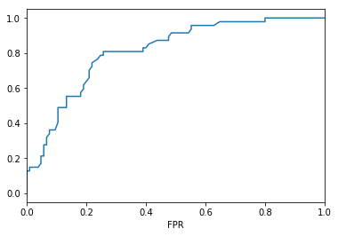

```python
import matplotlib.pyplot as plt
%matplotlib inline
ROC=model.stages[2].summary.roc
df=ROC.toPandas()

df.plot(x='FPR', y='TPR', legend=False)
```